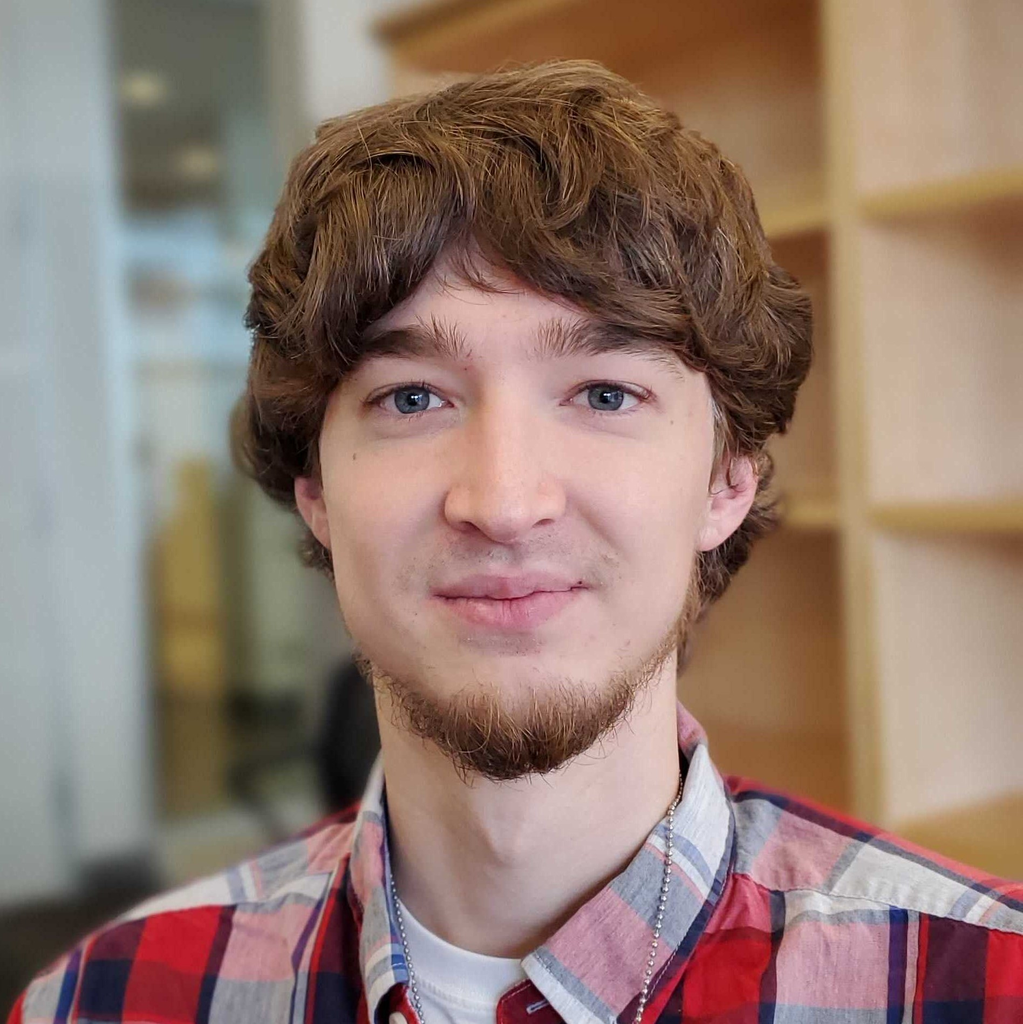

# Nicholas Eagles

## Bio

I’m currently a data scientist and bioinformatician in the [team](https://lcolladotor.github.io/bioc_team_ds/) led by Leonardo Collado-Torres at [LIBD](https://www.libd.org/).

Here, I design data pipelines, apply statistics and machine learning to better understand genomic data, and develop BI visualizations to communicate insights.

I also help [install and maintain software](https://github.com/LieberInstitute/jhpce_mod_source) for LIBD and collaborators, mentor and share my knowledge through [data science guidance sessions](https://lcolladotor.github.io/bioc_team_ds/data-science-guidance-sessions.html), and direct the [R Stats Club](http://research.libd.org/rstatsclub/). Some example topics I’ve taught there include [implementing machine-learning models in Python](https://youtu.be/-qFz7PwWEeY), [leveraging LLMs for data science](https://youtu.be/xuCQZ5_5KB0), and [running PyTorch-based software with GPUs at HPC environments](https://youtu.be/zOMUXYHtVJM).

I use technologies like R (tidyverse + Bioconductor), Python (pandas + scikit-learn), and git daily. I’ve also developed expertise with SQL, Databricks, Airflow, dbt, and Tableau.

## Portfolio

### Data Science Snippets

Here I showcase actual code I’ve developed for data-science tasks throughout my career.

- **Building machine-learning models**: [here](https://github.com/LieberInstitute/spatialDLPFC/blob/main/code/spot_deconvo/02-cellpose/10-explore_models.py) I use `scikit-learn` to train and test some candidate cell-type-classification models.
- **Data wrangling, cleaning, and visualization**: Beginning with several messy, large datasets, I use `dplyr` in R to [clean and integrate them.](https://github.com/LieberInstitute/Habenula_Pilot/blob/b7b670eafbd10093f94dafc62c787199d1fbd719/code/17_eQTL/08_beta_plots.R#L315-L374) Along the way, I [visualize key patterns](https://github.com/LieberInstitute/Habenula_Pilot/blob/b7b670eafbd10093f94dafc62c787199d1fbd719/code/17_eQTL/08_beta_plots.R#L229-L246) with `ggplot2`.
- **Deep learning**: In a personal project to build a neural-network-powered chess engine, I use Keras/Tensorflow to [build and fit a CNN-based model.](https://github.com/Nick-Eagles/Chess-Engine/blob/master/external/fit_real_data.py)

### Data Engineering Projects

These personal projects are heavier on the SQL, ETL/ELT pipelining, and data-warehouse-interaction side of things.

- **ELT pipeline + data warehouse**: [here](https://github.com/Nick-Eagles/customer_orders_ELT) I designed a data warehouse using the medallion architecture, and implemented an ELT pipeline using `dbt` and `Airflow` to populate it with cleaned, BI-ready tables.
- **Titanic Databricks project**: [here](https://github.com/Nick-Eagles/data_engineering_practice/tree/master/databricks/titanic_project) I engineer a Databricks workflow/ ETL pipeline with the well-known Titanic dataset touching `Pyspark`, Databricks notebooks + dashboards, Unity Catalog, and more. As a bonus I recreated the final visualizations with interactivity in Tableau [here](https://public.tableau.com/app/profile/nick.eagles/viz/TitanicDatasetKeyFindings/main_dashboard#1).

### Bioinformatics Pipelines

These are *Nextflow*-based pipelines for processing genomic data where I was the lead developer.

- **SPEAQeasy**: bulk RNA-seq preprocessing workflow, quantifying features like genes into `SummarizedExperiment` R objects ( [code](https://github.com/LieberInstitute/SPEAQeasy) | [documentation](http://lieberinstitute.github.io/SPEAQeasy) | [paper](https://doi.org/10.1186/s12859-021-04142-3))
- **BiocMAP**: preprocessing workflow for bisulfite sequencing data, quantifying methylation in `bsseq` R objects ( [code](https://github.com/LieberInstitute/BiocMAP) | [documentation](http://research.libd.org/BiocMAP/) | [paper](https://doi.org/10.1101/2022.04.20.488947))

## Education

**IBM** | Online

Data Science Professional Certification | October 2024 - January 2025

**University of Maryland, Baltimore County** | Baltimore, MD

B.S. in Mathematics | September 2013 - May 2018

## Experience

**Lieber Institute for Brain Development** | Research Associate II- Data Science | November 2018 - Present

## Publications

[Integrating gene expression and imaging data across Visium capture areas with visiumStitched](https://doi.org/10.1186/s12864-024-10991-y)

- Eagles et al., *BMC Genomics*, 2024.

[BiocMAP: a Bioconductor-friendly, GPU-accelerated pipeline for bisulfite-sequencing data](https://doi.org/10.1186/s12859-023-05461-3)

- Eagles et al., *BMC Bioinformatics*, 2023.

[SPEAQeasy: a scalable pipeline for expression analysis and quantification for R/bioconductor-powered RNA-seq analyses.](https://doi.org/10.1186/s12859-021-04142-3)

- Eagles et al., *BMC Bioinformatics*, 2021.

My full list of publications is available at my [ORCID profile](https://orcid.org/0000-0002-9808-5254).

## Public Presentations

**Galaxy and Bioconductor Conference** | 2025

- Presented a short talk: [Computational considerations for analysis of Visium HD—A Bioconductor user’s perspective](https://youtu.be/OFkQUw9FGI0?si=m0VZ9SMZB6MhXGRZ&t=1909)

**Bioconductor** | *Bioconductor* | 2023

- Presented a workshop: [A Bioconductor-style differential expression analysis powered by SPEAQeasy](http://research.libd.org/SPEAQeasyWorkshop2023/) recorded as a [video](https://www.youtube.com/watch?v=6hJXPw9PM1o)
- Presented a short talk: [Spot Deconvolution in the Post-Mortem Human DLPFC](https://speakerdeck.com/nickeagles/bioc-2023-spot-deconvolution) recorded as a [video](https://www.youtube.com/watch?v=YA5H2XP6jjU&t=700s)

**Biological Data Science** | *Cold Spring Harbor Laboratory* | 2022

- Presented a poster: [Benchmarking spot-level cell-type deconvolution methods using Visium immunofluorescence benchmark data on the human dorsolateral prefrontal cortex](https://speakerdeck.com/nickeagles/bds-2022).

**European Bioconductor** | *Bioconductor* | 2020

- Presented my [SPEAQeasy paper](https://www.youtube.com/watch?v=tPSG23hUHSI).